# Exercises Day 5: Trajectory inference and RNA velocity

**Goals:**

- Understand the requirements for RNA velocity computation
- Process scRNAseq using ‘spliced’ counts
- Perform lineage inference
- Compute RNA velocity and use it to orientate lineages

## 0. Prepare data from scratch

Because RNA velocity reflects the balance between immature and mature transcript content in each cell, one need to count the reads overlapping both spliced regions and unspliced regions. These counts are still generally not available when using public datasets. A way to generate them is to:

1. Get a `cellranger`-generated bam file of a scRNAseq experiment
2. Get the corresponding gene annotation file as a `gtf` file
3. Run `velocyto` to count reads mapped to introns or to exons

Let’s do this on a dataset published by Guo et al., Cell Res. 2018 ([doi: 10.1038/s41422-018-0099-2](https://doi.org/10.1038/s41422-018-0099-2)). There are 6 `bam` files corresponding to human male testis single-cell RNA-seq profiling ([GSE: GSE112013](https://www.ncbi.nlm.nih.gov/geo/query/acc.cgi?acc=GSE112013)).

> Download bam files from GEO

```bash
mkdir data/Guo_testis/
ffq -t GSE "GSE112013" | grep 'ftp://' | sed 's,.*ftp:,ftp:,' | sed 's,".*,,' > data/Guo_testis/GSE112013_bam-list.txt
for FILE in `cat data/Guo_testis/GSE112013_bam-list.txt | sed '$d'`
do
    echo $FILE
    curl ${FILE} -o data/Guo_testis/`basename ${FILE}`
done
```

To run `velocyto`, one needs to know where introns and exons are located in the genome reference used to process reads. In our case, `GRCh38` genome reference was used.

> Read `cellranger` instructions on how to generate a `gtf` file corresponding to GRCh38 genome reference [here](https://support.10xgenomics.com/single-cell-gene-expression/software/release-notes/build#GRCh38_2020A).  
> Create `GRCh38` gene annotation gtf file following Cellranger recommendations

```bash
mkdir data/Guo_testis/genome
curl http://ftp.ebi.ac.uk/pub/databases/gencode/Gencode_human/release_32/gencode.v32.primary_assembly.annotation.gtf.gz -o data/Guo_testis/genome/gencode.v32.primary_assembly.annotation.gtf.gz
gunzip data/Guo_testis/genome/gencode.v32.primary_assembly.annotation.gtf.gz
ID="(ENS(MUS)?[GTE][0-9]+)\.([0-9]+)"
cat data/Guo_testis/genome/gencode.v32.primary_assembly.annotation.gtf \
    | sed -E 's/gene_id "'"$ID"'";/gene_id "\1"; gene_version "\3";/' \
    | sed -E 's/transcript_id "'"$ID"'";/transcript_id "\1"; transcript_version "\3";/' \
    | sed -E 's/exon_id "'"$ID"'";/exon_id "\1"; exon_version "\3";/' \
    > data/Guo_testis/genome/gencode.v32.primary_assembly.annotation_modified.gtf
cat data/Guo_testis/genome/gencode.v32.primary_assembly.annotation_modified.gtf \
    | awk '$3 == "transcript"' \
    | grep -E "$GENE_PATTERN" \
    | grep -E "$TX_PATTERN" \
    | grep -Ev "$READTHROUGH_PATTERN" \
    | grep -Ev "$PAR_PATTERN" \
    | sed -E 's/.*(gene_id "[^"]+").*/\1/' \
    | sort \
    | uniq \
    > data/Guo_testis/genome/gene_allowlist
grep -E "^#" data/Guo_testis/genome/gencode.v32.primary_assembly.annotation_modified.gtf > data/Guo_testis/genome/gencode.v32.primary_assembly.annotation_filtered.gtf
grep -Ff data/Guo_testis/genome/gene_allowlist data/Guo_testis/genome/gencode.v32.primary_assembly.annotation_modified.gtf \
    | sed -E 's,^chr,,' \
    | sed -E 's,^M\t,MT\t,' \
    >> data/Guo_testis/genome/gencode.v32.primary_assembly.annotation_filtered.gtf
```

To make the `velocyto` step faster, one can only use reads from bam files originating from cell-containing droplets. One way to do so is to extract cell barcodes from the already filtered scRNAseq dataset, and use them in the `-b` argument of `velocyto`.

> (Optional) Get cell barcodes from cellranger (this requires pre-processed scRNAseq data, available from GEO)

```r
library(tidyverse)
vroom::vroom('data/Guo_testis/GSE112013_Combined_UMI_table.txt') %>%
    colnames() %>%
    str_replace_all('Donor.-', '') %>%
    tail(-1) %>%
    unique() %>%
    writeLines('data/Guo_testis/testis_cell-barcodes.txt')
```

By now, we have obtained 3 different files:

1. BAM files of scRNAseq data mapped onto GRCh38
2. GTF file of GRCh38 gene annotations
3. A barcode file for BAM file pre-filtering

> Run velocyto on each sample

```bash
mkdir data/Guo_testis/velocyto
for FILE in `cat data/Guo_testis/GSE112013_bam-list.txt`
do
    curl ${FILE} -o data/Guo_testis/`basename ${FILE}`
    velocyto run \
        -b data/Guo_testis/testis_cell-barcodes.txt \
        -o data/Guo_testis/velocyto/ \
        --samtools-threads 15 \
        -vv \
        data/Guo_testis/`basename ${FILE}` \
        data/Guo_testis/genome/gencode.v32.primary_assembly.annotation_filtered.gtf
    rm data/Guo_testis/`basename ${FILE}`
done
```

We have obtained six `loom` files, but ideally we want them merged as a single `SingleCellExperiment` object readable in R.

> Read about `LoomExperiment` package. Is there an easy (and reliable) way to import loom files in R? Merge loom files directly in R and save the resulting object as a `rds` binary file.

```r
library(tidyverse)
library(LoomExperiment)
looms <- list.files('data/Guo_testis/velocyto/', full.names = TRUE) %>%
    lapply(LoomExperiment::import) %>%
    do.call(cbind, .)
looms$sample <- str_replace_all(looms$CellID, ':.*', '')
looms$Barcode <- str_replace_all(looms$CellID, '.*:', '') %>% str_replace('x', '')
# Some additional tidying up...
# testis_2 <- testis[rownames(testis)[rownames(testis) %in% rowData(looms)$Gene], ]
# genes <- rownames(testis_2)
# bcs <- testis_2$Barcode
# looms <- looms[match(genes, rowData(looms)$Gene), ]
# looms <- scuttle::aggregateAcrossCells(looms, looms$Barcode, use.assay.type = c('spliced', 'unspliced'))
# looms <- looms[, match(bcs, looms$Barcode)]
#
saveRDS(looms, 'data/Guo_testis/testis_velocity-counts.rds')
```

## 1. Process testis data in R

The same workflow than previous days can be reused here.

> Import testis dataset in R, filter cells and genes, normalize `counts`, embed data and cluster cells.

```r
library(SingleCellExperiment)
library(tidyverse)
download.file(
    'https://ftp.ncbi.nlm.nih.gov/geo/series/GSE112nnn/GSE112013/suppl/GSE112013_Combined_UMI_table.txt.gz',
    'data/Guo_testis/GSE112013_Combined_UMI_table.txt.gz'
)
system('gunzip data/Guo_testis/GSE112013_Combined_UMI_table.txt.gz')
x <- vroom::vroom('data/Guo_testis/GSE112013_Combined_UMI_table.txt')
cnts <- as.matrix(x[, -1])
gData <- as.data.frame(x[, 1])
cData <- data.frame(cellid = colnames(x[, -1]))
testis <- SingleCellExperiment(
    assays = list(counts = cnts),
    colData = cData,
    rowData = gData
)
testis$Barcode <- str_replace(testis$cellid, 'Donor.-', '') %>% str_replace('-.', '')
testis <- testis[, !duplicated(testis$Barcode)]
testis$donor <- str_replace(testis$cellid, '-.*', '')
testis$replicate <- str_replace(testis$cellid, '.*-', '')
rownames(testis) <- rowData(testis)$Gene
set.seed(1000)

# Remove doublets
testis <- scDblFinder::scDblFinder(testis)
testis <- testis[, testis$scDblFinder.class == 'singlet']

# Recover human genomic, protein-coding gene informations
library(plyranges)
ah <- AnnotationHub::AnnotationHub()
AnnotationHub::query(ah, c('gene annotation', 'ensembl', '102', 'homo_sapiens', 'GRCh38'))
gtf <- AnnotationHub::query(ah, c('Homo_sapiens.GRCh38.102.chr.gtf'))[[1]]
genes <- gtf %>%
    filter(type == 'gene') %>%
    filter(gene_biotype == 'protein_coding') %>%
    filter(gene_source == 'ensembl_havana')
genes <- genes[!duplicated(genes$gene_name)]

# Annotate genes in testis dataset and filter out non-relevant genes
testis <- testis[genes$gene_name[genes$gene_name %in% rownames(testis)], ]
rowRanges(testis) <- genes[match(rownames(testis), genes$gene_name)]
rowData(testis) <- rowData(testis)[, c('gene_name', 'gene_id')]
rownames(testis) <- scuttle::uniquifyFeatureNames(rowData(testis)$gene_id, rowData(testis)$gene_name)

# Get preliminary QCs per cell and per gene
testis <- scuttle::addPerCellQCMetrics(testis)
testis <- scuttle::addPerFeatureQCMetrics(testis)

# Filter out genes not expressed in at least 10 cells
testis <- testis[rowSums(assay(testis, 'counts') > 0) >= 10, ]

# Normalize counts using VST
cnts <- as(assay(testis, 'counts'), 'dgCMatrix')
colnames(cnts) <- testis$cellid
rownames(cnts) <- rownames(testis)
testis_vst <- sctransform::vst(cnts, return_cell_attr = TRUE)
corrected_cnts <- sctransform::correct(testis_vst)
assay(testis, 'corrected_counts', withDimnames = FALSE) <- corrected_cnts
assay(testis, 'logcounts', withDimnames = FALSE) <- log1p(corrected_cnts)

# Computing biological variance of each gene
testis_variance <- scran::modelGeneVar(testis)
HVGs <- scran::getTopHVGs(testis_variance, prop = 0.1)
rowData(testis)$isHVG <- rownames(testis) %in% HVGs

# Embedding dataset in PCA space, correcting for batch effect
mergedBatches <- batchelor::fastMNN(
    testis,
    batch = testis$donor,
    subset.row = HVGs,
    BPPARAM = BiocParallel::MulticoreParam(workers = 12)
)
reducedDim(testis, 'corrected') <- reducedDim(mergedBatches, 'corrected')

# Embedding dataset in shared k-nearest neighbors graph for clustering
graph <- scran::buildSNNGraph(testis, use.dimred = 'corrected')

# Cluster cells using Louvain community finding algorithm
testis_clust <- igraph::cluster_louvain(graph)$membership
table(testis_clust)
testis$cluster <- factor(testis_clust)

# Embedding dataset in TSNE space for visualization
set.seed(10)
testis <- scater::runTSNE(testis, dimred = 'corrected')
p <- cowplot::plot_grid(
    scater::plotReducedDim(testis, 'corrected', colour_by = 'donor'),
    scater::plotReducedDim(testis, 'corrected', colour_by = 'cluster'),
    scater::plotReducedDim(testis, 'TSNE', colour_by = 'donor'),
    scater::plotReducedDim(testis, 'TSNE', colour_by = 'cluster')
)
```

> Load `HPA` data [from internet](https://www.proteinatlas.org/download/rna_single_cell_type.tsv.zip). Try to format it as a `SummarizedExperiment`. What celltypes are profiled? Use these cell type profiles to annotate cell types in the testis dataset. How do the annotations look like? Can you find a reason why the label transfer worked so well?

```r
download.file(
    'https://www.proteinatlas.org/download/rna_single_cell_type.tsv.zip',
    'data/Guo_testis/rna_single_cell_type.tsv.zip'
)
system('unzip data/Guo_testis/rna_single_cell_type.tsv.zip')
system('mv rna_single_cell_type.tsv data/Guo_testis/')
HPA <- vroom::vroom('data/Guo_testis/rna_single_cell_type.tsv') %>%
    pivot_wider(names_from = `Cell type`, values_from = 'NX') %>%
    dplyr::select(-Gene) %>%
    distinct(`Gene name`, .keep_all = TRUE) %>%
    column_to_rownames('Gene name') %>%
    SummarizedExperiment::SummarizedExperiment(assays = list('logcounts' = .))

# Transfer annotations to `testis`
predictions <- SingleR::SingleR(
    test = testis,
    ref = HPA,
    labels = colnames(HPA)
)
table(predictions$labels, testis$cluster)
labels <- table(predictions$labels, testis$cluster) %>%
    data.matrix() %>%
    apply(2, which.max) %>%
    sort(unique(predictions$labels))[.]
names(labels) <- 1:length(labels)
testis$annotation <- labels[testis$cluster]
p <- cowplot::plot_grid(
    scater::plotReducedDim(testis, dimred = 'corrected', colour_by = 'cluster', text_by = 'cluster') + ggtitle('Testis data, PCA, graph-based clusters'),
    scater::plotReducedDim(testis, dimred = 'corrected', colour_by = 'annotation', text_by = 'annotation') + ggtitle('PCA, Annotations transferred from HPA'),
    scater::plotReducedDim(testis, dimred = 'TSNE', colour_by = 'cluster', text_by = 'cluster') + ggtitle('Testis data, tSNE, graph-based clusters'),
    scater::plotReducedDim(testis, dimred = 'TSNE', colour_by = 'annotation', text_by = 'annotation') + ggtitle('tSNE, Annotations transferred from HPA')
)
```

## 2. Trajectory inference (TI) in scRNAseq

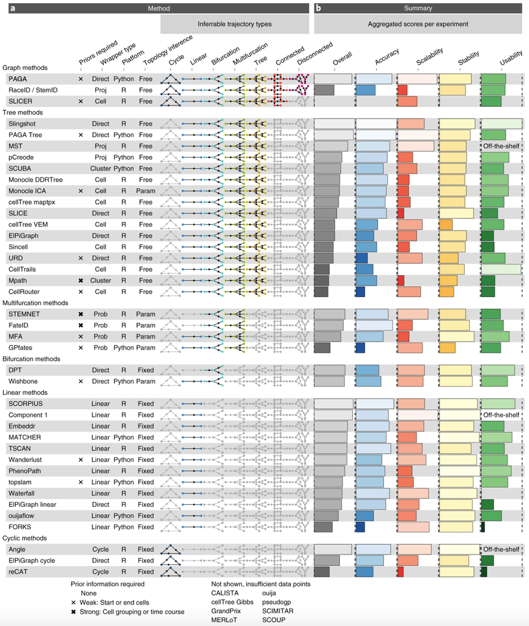

### Slingshot

`Slingshot` is perhaps one of the most widely used algorithms for users who want to focus on `R`-based approaches.

> Read Slingshot documentation to understand how to identify lineages in a scRNAseq dataset in R  
> Infer lineages in the testis dataset  
> Why is it recommended to infer lineages from PCA space rather than t-SNE or UMAP space, even though these spaces do “reveal” an obvious trajectory in 2D?

```r
testis_slingshot <- slingshot::slingshot(testis, reducedDim = 'corrected')
testis_slingshot
slingshot::slingLineages(testis_slingshot)
```

> Check the inferred trajectory(ies) in 2D projection. You can use the `embedCurves()` to embed the curves in any given dimensional space. Do they fit your expectations?

```r
pca_curve <- slingCurves(testis_slingshot, as.df = TRUE)
colnames(pca_curve) <- paste0('PC', 1:ncol(pca_curve))
tsne_curve <- slingshot::embedCurves(testis_slingshot, 'TSNE', smoother = 'loess', span = 0.1) %>% slingCurves(as.df = TRUE)
tsne_curve <- tsne_curve[order(tsne_curve$Order), ]
colnames(tsne_curve)[1:2] <- paste0('TSNE', 1:ncol(tsne_curve))
df <- tibble(
    PC1 = reducedDim(testis, 'corrected')[,1],
    PC2 = reducedDim(testis, 'corrected')[,2],
    TSNE1 = reducedDim(testis, 'TSNE')[,1],
    TSNE2 = reducedDim(testis, 'TSNE')[,2],
    cluster = testis$cluster
)
p <- cowplot::plot_grid(
    df %>%
        ggplot() +
        geom_point(aes(PC1, PC2, col = cluster)) +
        geom_path(data = pca_curve, aes(x = PC1, y = PC2)) +
        theme_bw() +
        coord_fixed(),
    df %>%
        ggplot() +
        geom_point(aes(TSNE1, TSNE2, col = cluster)) +
        geom_path(data = tsne_curve, aes(x = TSNE1, y = TSNE2)) +
        theme_bw() +
        coord_fixed()
)
```

> Filter the testis dataset to only germinal cells.  
> Re-infer lineages, using cluster annotations as information to build the MST. Note that you will first need to remove the 50th PCA dimension for `slingshot` to work (bug reported).  
> What do you observe? Discuss.

```r
germcells <- testis[, testis$annotation %in% c("Spermatogonia", "Spermatocytes", "Early spermatids", "Late spermatids")]
reducedDim(germcells, 'corrected_2') <- reducedDim(germcells, 'corrected')[, 1:49]
germcells_slingshot <- slingshot::slingshot(
    germcells,
    reducedDim = 'corrected_2',
    clusterLabels = germcells$cluster
)
germcells$pseudotime <- slingshot::slingPseudotime(germcells_slingshot)[, 'Lineage1']

pca_curve <- slingCurves(germcells_slingshot, as.df = TRUE)
colnames(pca_curve) <- paste0('PC', 1:ncol(pca_curve))
tsne_curve <- slingshot::embedCurves(germcells_slingshot, 'TSNE', smoother = 'loess', span = 0.1) %>% slingCurves(as.df = TRUE)
tsne_curve <- tsne_curve[order(tsne_curve$Order), ]
colnames(tsne_curve) <- paste0('TSNE', 1:ncol(tsne_curve))
df <- tibble(
    PC1 = reducedDim(germcells, 'corrected')[,1],
    PC2 = reducedDim(germcells, 'corrected')[,2],
    TSNE1 = reducedDim(germcells, 'TSNE')[,1],
    TSNE2 = reducedDim(germcells, 'TSNE')[,2],
    cluster = germcells$cluster,
    pseudotime = germcells$pseudotime
)
p <- cowplot::plot_grid(
    df %>%
        ggplot() +
        geom_point(aes(PC1, PC2, col = cluster)) +
        geom_path(data = pca_curve, aes(x = PC1, y = PC2)) +
        theme_bw() +
        coord_fixed(),
    df %>%
        ggplot() +
        geom_point(aes(TSNE1, TSNE2, col = cluster)) +
        geom_path(data = tsne_curve, aes(x = TSNE1, y = TSNE2)) +
        theme_bw() +
        coord_fixed(),
    df %>%
        ggplot() +
        geom_point(aes(PC1, PC2, col = pseudotime)) +
        geom_path(data = pca_curve, aes(x = PC1, y = PC2)) +
        theme_bw() +
        coord_fixed(),
    df %>%
        ggplot() +
        geom_point(aes(TSNE1, TSNE2, col = pseudotime)) +
        geom_path(data = tsne_curve, aes(x = TSNE1, y = TSNE2)) +
        theme_bw() +
        coord_fixed()
)
```

### Pseudotime inference and expression modelling

The pseudotime is a metric describing the relative position of a cell in the trajectory, where cells with larger values are consider to be “after” their counterparts with smaller values. In trajectories describing time-dependent processes like differentiation, a cell’s pseudotime value is generally used as a proxy for its relative age.

#### Pseudotime inference

> Extract the pseudotime values automatically computed by `slingshot`. Check the distribution of pseudotime values across the different cell clusters. What do you observe? Where you expecting this?

```r
p <- tibble(
    annotation = factor(germcells$annotation, c("Spermatogonia", "Spermatocytes", "Early spermatids", "Late spermatids")),
    pseudotime = germcells$pseudotime
) %>%
    ggplot(aes(x = annotation, y = pseudotime, fill = annotation)) +
    geom_violin(scale = 'width') +
    geom_boxplot(outlier.shape = NULL, width = 0.1, fill = 'white') +
    theme_bw() +
    theme(axis.text.x = element_text(angle = 45, hjust = 1, vjust = 1))
```

> Correct pseudotime values as you would expect it to be.

```r
germcells$pseudotime <- scales::rescale((-1 * slingshot::slingPseudotime(germcells_slingshot)[, 'Lineage1']), c(0, 1))
```

#### [BONUS] Daunting snippet but that makes a cool figure for a paper: modeling pseudotime-dependent gene expression

Using pseudotime / cell, one can model gene expression along the differentiation process. This alleviates the need to study gene expression **per cell**, and allows one to focus on process-related effects (e.g. gene expression during a developmental trajectory).

> Try to do so for few markers of spermatogonia, spermatocytes and spermatids.

```r
genes <- c(
    'ID4', 'SYCP3', 'DMC1',
    'ACR', 'PRM1', 'PGK2'
)
fitExprs <- logcounts(germcells[genes, ]) %>% # ----------------------------------- Get norm. counts for genes of interest
    as.matrix() %>%
    t() %>%
    as_tibble() %>%
    mutate(  # ----------------------------------------------------------------- Add information for each cell
        cellID = colnames(germcells),
        annotation = factor(germcells$annotation, c("Spermatogonia", "Spermatocytes", "Early spermatids", "Late spermatids")),
        pseudotime = germcells$pseudotime
    ) %>%
    pivot_longer(contains(genes), names_to = 'gene', values_to = 'obs_expr') %>% # - Pivot in "long" tidy format
    mutate(gene = factor(gene, genes)) %>%
    group_by(gene) %>% # ------------------------------------------------------- Group rows by genes
    nest(.key = 'data') %>% # -------------------------------------------------- For each gene, extract the subtable into a column named data
    mutate(
        gamModel = map(data, ~mgcv::gam(obs_expr ~ s(pseudotime, bs = "cs"), data = .)),
        gamFitted_expr = map(gamModel, predict) # ------------------------------ For each gene, fit the expression values ~ pseudotime with a GAM
    ) %>%
    dplyr::select(-ends_with('Model')) %>%
    unnest(c(data, ends_with('_expr'))) # -------------------------------------- Unnest all the modelled expressions
p <- ggplot(fitExprs) +
    ggrastr::geom_point_rast(aes(x = pseudotime, y = obs_expr, col = annotation), alpha = 0.5) +
    geom_line(aes(x = pseudotime, y = gamFitted_expr), col = 'white', size = 2, alpha = 0.5) +
    geom_line(aes(x = pseudotime, y = gamFitted_expr), col = '#af2d0c', size = 1) +
    theme_bw() +
    facet_grid(gene~., scales = 'free') +
    labs(y = 'logcounts') +
    ggtitle('Fitted models of pseudotime-dependent gene expression')
```

## 3. Ordering trajectory with RNA velocity

As we saw earlier, TI does not necessarily know which direction is right for a given trajectory. This can be safely estimated using RNA velocity. For a given gene, a high ratio of unspliced to spliced transcripts indicates that that gene is being actively upregulated. Conversely, a low ratio indicates that the gene is being downregulated as the rate of production and processing of pre-mRNAs cannot compensate for the degradation of mature transcripts. Thus, we can infer that cells with high and low ratios are moving towards a high- and low-expression state, respectively, allowing us to assign directionality to trajectories or even individual cells.

> Read `velociraptor` documentation. What do you need to compute RNA velocity scores in R? Import `spliced` and `unspliced` counts computed with `velocyto` in R. Try and compute RNA velocity (on germcells only). What do you see?

```r
looms <- readRDS('data/Guo_testis/testis_velocity-counts.rds')
assays(looms)
rownames(looms) <- rowData(looms)$Gene
testis <- testis[rownames(looms), ]
assay(testis, 'spliced', withDimnames=FALSE) <- assay(looms, 'spliced')
assay(testis, 'unspliced', withDimnames=FALSE) <- assay(looms, 'unspliced')
germcells <- testis[, testis$annotation %in% c("Spermatogonia", "Spermatocytes", "Early spermatids", "Late spermatids")]
velo_out <- velociraptor::scvelo(
    germcells,
    assay.X = "counts",
    use.dimred = "corrected",
    subset.row = scran::getTopHVGs(scran::modelGeneVar(germcells), prop = 0.1),
    mode = 'dynamical'
)
embedded_velo <- velociraptor::embedVelocity(reducedDim(germcells, "TSNE"), velo_out)
grid.df <- velociraptor::gridVectors(reducedDim(germcells, "TSNE"), embedded_velo, resolution = 30)
p <- scater::plotReducedDim(germcells, 'TSNE', colour_by = "annotation", point_alpha = 0.5) +
    geom_segment(
        data = grid.df,
        mapping = aes(x = start.1, y = start.2, xend = end.1, yend = end.2),
        arrow = arrow(length = unit(0.05, "inches"), type = "closed")
    )
```